# Amirali Rahimi 810100146

# CA6 - Clustering

# Problem Description

In this problem we have some news that have 6 different categories:

- فناوری
- ورزشی
- حوادث
- سلامت
- سیاسی
- فرهنگی/هنری

We are going to train a model that clusters our data using `K-Means` and `DB-SCAN` method and test the trained model.

```python
import pandas as pd
import hazm
from gensim.models.doc2vec import Doc2Vec, TaggedDocument
from sklearn.cluster import KMeans, DBSCAN
from sklearn.decomposition import PCA
import matplotlib.pyplot as plt
from sklearn.metrics import homogeneity_score, silhouette_score
```

```python
class LabelHandler:
    labels = [
        "فناوری",
        "ورزشی",
        "حوادث",
        "سلامت",
        "سیاسی",
        "فرهنگی/هنری"
    ]

    def labelToNum(self, label):
        return self.labels.index(label)

labelHandler = LabelHandler()
```

## Question 1: Explain what problems would occur in the clustering process if the data were unbalanced? Explain some strategies that can fix this prblems.

### Problems:

- **Larger Cluster Dominance:** Larger clusters may overshadow and dominate over smaller ones.
- **Poor Minority Representation:** Smaller clusters might be poorly represented or considered as outliers.
- **Inaccurate Evaluation Metrics:** Standard metrics may not accurately reflect the quality of clustering due to imbalance.
- **Cluster Number Determination:** Difficulty in determining the right number of clusters in unbalanced datasets.
- **Overfitting Risk:** There's a potential risk of the model overfitting to larger clusters.

### Solutions:

- **Algorithm Selection:** Use algorithms less sensitive to cluster size, like density-based methods (e.g., DBSCAN).
- **Oversampling & Adjustment:** Implement oversampling for smaller clusters or adjust the algorithm to focus more on them.
- **Robust Metrics:** Employ more robust evaluation metrics, such as silhouette scores.
- **Advanced Techniques:** Utilize advanced methods like the Gap statistic or stability analysis for optimal cluster number determination.
- **Regularization & Modification:** Apply regularization techniques or modify the clustering algorithm to reduce large cluster bias.

# Data Preprocessing

Since our data has equal samples of every category, we skip equalizing category sample numbers. So we start by normalizing the data.

## Normalizing

```python
def printFirstData(traindf, testdf, operation):
    print(f"First train data after {operation}")
    print(traindf.iloc[0]["content"])
    print(f"First test data after {operation}")
    print(testdf.iloc[0]["content"])
```

```python
trainData = pd.read_csv("train.csv")
trainData.info()
trainData.describe()
trainData.head()
my_normalizer = hazm.Normalizer()
print("First train data before normalizing:")
print(trainData.iloc[0]["content"])
trainData["content"].apply(my_normalizer.normalize)
```

```
<class 'pandas.core.frame.DataFrame'>
RangeIndex: 9000 entries, 0 to 8999
Data columns (total 2 columns):
 #   Column   Non-Null Count  Dtype
---  ------   --------------  -----
 0   label    9000 non-null   object
 1   content  9000 non-null   object
dtypes: object(2)
memory usage: 140.8+ KB
First train data before normalizing:
گزارش های منتشر شده حاکی از آن است که کاربران تلگرام در مناطقی از جهان همچون اروپا و خاورمیانه با مشکل مواجه شده اند. به گزارش ایسنا، به نقل از تلگرام، دقایقی پیش پیام رسان تلگرام در صفحه توییتر خود اعلام کرد که دسترسی کاربران این اپلیکیشن در اروپا و خاورمیانه با مشکل مواجه شده است. طبق این پیام، به…
```

```
0       گزارش‌های منتشر شده حاکی از آن است که کاربران ...
1       سوپر استار سینما و از قهرمانان سابق ووشو کونگ‌...
2       مدیرعامل شرکت عمران آب کیش از فوت یک نفر در آت...
3       یک نوجوان انگلیسی به اتهام هک حساب‌های کاربری ...
4       دانشمندان در جدیدترین مطالعات خود اثرات جدید و...
                              ...
8995    شانزدهم مهر امسال درپی تماس با مرکز فوریت‌های ...
8996    اتحادیه فوتبال ترینیداد و توباگو اعلام کرده تی...
8997    اسامی ۱۸ فیلم بخش مسابقه مستند ششمین دوره جشنو...
8998    کامیونت حامل بار تخته‌های چوبی عصر دیروز چهارش...
8999    چهارمین لیگ بازی‌های رایانه‌ای ایران از روز ۶ ...
Name: content, Length: 9000, dtype: object
```

```python
testData = pd.read_csv("test.csv")
testData.info()
testData.describe()
testData.head()
my_normalizer = hazm.Normalizer()
print("First test data before normalizing:")
print(testData.iloc[0]["content"])
trainData["content"].apply(my_normalizer.normalize)
```

```
<class 'pandas.core.frame.DataFrame'>
RangeIndex: 1115 entries, 0 to 1114
Data columns (total 2 columns):
 #   Column   Non-Null Count  Dtype
---  ------   --------------  -----
 0   label    1115 non-null   object
 1   content  1115 non-null   object
dtypes: object(2)
memory usage: 17.6+ KB
First test data before normalizing:
بعد از اعلام لیست ۲۳ شرکت مجاز ثبت سفارش و ارائه خدمات پس از فروش تلفن‌های همراه سازمان حمایت تولیدکنندگان و مصرف‌کنندگان بخش‌هایی از این لیست را اصلاح کرد. به گزارش ایسنا، چندی پیش براساس مصوبه‌ای، تصمیم بر این شد که دیگر ثبت سفارش هیچ کالای مصرفی بدون خدمات پس از فروش از طریق نمایندگی‌های رسمی صور…
```

```
0       گزارش‌های منتشر شده حاکی از آن است که کاربران ...
1       سوپر استار سینما و از قهرمانان سابق ووشو کونگ‌...
2       مدیرعامل شرکت عمران آب کیش از فوت یک نفر در آت...
3       یک نوجوان انگلیسی به اتهام هک حساب‌های کاربری ...
4       دانشمندان در جدیدترین مطالعات خود اثرات جدید و...
                              ...
8995    شانزدهم مهر امسال درپی تماس با مرکز فوریت‌های ...
8996    اتحادیه فوتبال ترینیداد و توباگو اعلام کرده تی...
8997    اسامی ۱۸ فیلم بخش مسابقه مستند ششمین دوره جشنو...
8998    کامیونت حامل بار تخته‌های چوبی عصر دیروز چهارش...
8999    چهارمین لیگ بازی‌های رایانه‌ای ایران از روز ۶ ...
Name: content, Length: 9000, dtype: object
```

```python
printFirstData(trainData, testData, "normalizing")
```

```
First train data after normalizing
گزارش های منتشر شده حاکی از آن است که کاربران تلگرام در مناطقی از جهان همچون اروپا و خاورمیانه با مشکل مواجه شده اند. به گزارش ایسنا، به نقل از تلگرام، دقایقی پیش پیام رسان تلگرام در صفحه توییتر خود اعلام کرد که دسترسی کاربران این اپلیکیشن در اروپا و خاورمیانه با مشکل مواجه شده است. طبق این پیام، به…
First test data after normalizing
بعد از اعلام لیست ۲۳ شرکت مجاز ثبت سفارش و ارائه خدمات پس از فروش تلفن‌های همراه سازمان حمایت تولیدکنندگان و مصرف‌کنندگان بخش‌هایی از این لیست را اصلاح کرد. به گزارش ایسنا، چندی پیش براساس مصوبه‌ای، تصمیم بر این شد که دیگر ثبت سفارش هیچ کالای مصرفی بدون خدمات پس از فروش از طریق نمایندگی‌های رسمی صور…
```

## Tokenizing

```python
tokenizer = hazm.WordTokenizer()
trainData["content"] = trainData["content"].apply(tokenizer.tokenize)
testData["content"]  = testData["content"].apply(tokenizer.tokenize)
printFirstData(trainData, testData, "tokenizing")
```

```
First train data after tokenizing
['گزارش', 'های', 'منتشر', 'شده', 'حاکی', 'از', 'آن', 'است', 'که', 'کاربران', 'تلگرام', 'در', 'مناطقی', 'از', 'جهان', 'همچون', 'اروپا', 'و', 'خاورمیانه', 'با', 'مشکل', 'مواجه', 'شده_اند', '.', 'به', 'گزارش', 'ایسنا', '،', 'به', 'نقل', 'از', 'تلگرام', '،', 'دقایقی', 'پیش', 'پیام', 'رسان', 'تلگرام', 'د…
First test data after tokenizing
['بعد', 'از', 'اعلام', 'لیست', '۲۳', 'شرکت', 'مجاز', 'ثبت', 'سفارش', 'و', 'ارائه', 'خدمات', 'پس', 'از', 'فروش', 'تلفن\u200cهای', 'همراه', 'سازمان', 'حمایت', 'تولیدکنندگان', 'و', 'مصرف\u200cکنندگان', 'بخش\u200cهایی', 'از', 'این', 'لیست', 'را', 'اصلاح', 'کرد', '.', 'به', 'گزارش', 'ایسنا', '،', 'چندی',…
```

## Question 2: Explain How stemming and lemmatization works.

Stemming and lemmatization are two foundational techniques in natural language processing (NLP) for reducing words to their base or root form. They are critical in pre-processing stages, particularly when standardizing textual data for various NLP tasks like search, text classification, or sentiment analysis.

### Stemming

- **Definition:** Stemming simplifies words to their stem or root form, which may not be a valid word itself.
- **Method:** It typically involves chopping off word endings based on common prefixes or suffixes.
- **Usage:** Useful in information retrieval to increase search flexibility.
- **Limitation:** It might result in stems that are not actual words, leading to less accurate semantic understanding.

### Lemmatization

- **Definition:** Lemmatization reduces words to their base or dictionary form (lemma), ensuring the reduced form is a valid word.
- **Method:** It involves more sophisticated linguistic analysis, considering the word's part of speech, tense, number, and context.
- **Usage:** Ideal for tasks requiring precise language understanding.
- **Limitation:** More computationally intensive than stemming.

### Comparison

- **Precision:** Lemmatization is generally more precise than stemming.
- **Performance:** Stemming is faster but might be less accurate.
- **Application:** The choice depends on the need for accuracy vs. processing speed in the specific NLP task.

### Conclusion

Both stemming and lemmatization are crucial in text normalization. The choice between them should align with the specific requirements of the NLP application, balancing between precision and computational efficiency.

## Stemizing

```python
def stemizeList(words):
    stemmer = hazm.Stemmer()
    new_list = []
    for word in words:
        new_list.append(stemmer.stem(word))
    return new_list
```

```python
trainData["content"] = trainData["content"].apply(stemizeList)
testData["content"]  = testData["content"].apply(stemizeList)
printFirstData(trainData, testData, "normalizing")
```

```
First train data after normalizing
['گزار', '', 'منتشر', 'شده', 'حاک', 'از', 'آن', 'اس', 'که', 'کاربر', 'تلگرا', 'در', 'مناطق', 'از', 'جه', 'همچون', 'اروپا', 'و', 'خاورمیانه', 'با', 'مشکل', 'مواجه', 'شده_اند', '.', 'به', 'گزار', 'ایسنا', '،', 'به', 'نقل', 'از', 'تلگرا', '،', 'دقایق', 'پ', 'پیا', 'رس', 'تلگرا', 'در', 'صفحه', 'تو', 'خو…
First test data after normalizing
['بعد', 'از', 'اعلا', 'لیس', '۲۳', 'شرک', 'مجاز', 'ثب', 'سفار', 'و', 'ارائه', 'خد', 'پس', 'از', 'فرو', 'تلفن', 'همراه', 'ساز', 'حما', 'تولیدکنندگ', 'و', 'مصرف\u200cکنندگ', 'بخش', 'از', 'این', 'لیس', 'را', 'اصلاح', 'کرد', '.', 'به', 'گزار', 'ایسنا', '،', 'چند', 'پ', 'براساس', 'مصوبه', '،', 'تصم', 'بر…
```

# Training the Model

## Question 3: Explain the reason for using the feature vector and its features.

In clustering, which is a form of unsupervised machine learning, feature vectors are critical. They provide a structured, numerical way of representing data, enabling algorithms to identify patterns and group similar items.

### Importance of Feature Vectors in Clustering

1. **Numerical Representation:** Clustering algorithms require numerical data to measure similarities or differences. Feature vectors convert raw data (like text or images) into a form that these algorithms can process.
2. **Dimensionality:** They help in managing the dimensionality of the data. High-dimensional data can be reduced to a more manageable form while retaining essential characteristics, crucial for effective clustering.
3. **Standardization:** Feature vectors standardize data inputs, ensuring consistency across different data points. This uniformity is vital for unbiased clustering.
4. **Distance Measurement:** Clustering often relies on distance metrics (like Euclidean or Manhattan distance). Feature vectors provide the numerical basis for calculating these distances.

### Key Features in Clustering

1. **Relevance:** Features included in the vector should be relevant to the clustering task, capturing characteristics that define the clusters.
2. **Scale:** The scale of features should be normalized to prevent features with larger ranges from dominating the distance calculations.
3. **Diversity:** A good feature vector should include a diverse set of features to capture different aspects of the data, aiding in more nuanced clustering.
4. **Sparsity:** In datasets with many features, vectors often become sparse. Techniques like dimensionality reduction can help to manage sparsity.

### Conclusion

Feature vectors are essential in clustering for transforming diverse and complex datasets into a structured, numerical format. The selection and treatment of these features significantly influence the effectiveness and accuracy of the clustering process.

## Question 4: Explain how vec2word and vec2doc work and convert text to feature vector.

### vec2word: Word Embeddings

- Converts individual words into vectors.
- Utilizes algorithms like Word2Vec to analyze words in context.
- Produces multi-dimensional vectors where similar words have similar vectors.
- Used in NLP tasks like sentiment analysis and text classification.

### vec2doc: Document Embeddings

- Represents larger text blocks (sentences, documents) as vectors.
- Aggregates word vectors using methods like averaging or Doc2Vec.
- Captures the context of the entire text.
- Applied in document classification and information retrieval.

### Conclusion

vec2word and vec2doc are key in NLP for converting text to numerical vectors, with vec2word focusing on words and vec2doc on larger text segments.

## Question 5: K-Means and DBSCAN: Overview, Advantages, and Disadvantages

### K-Means Clustering

K-Means is a partitioning method that divides the data into K clusters. It assigns points to the nearest cluster center and recalculates the centers until convergence.

- **Advantages:**
  - **Efficiency:** Fast and efficient for large datasets.
  - **Ease of Implementation:** Relatively simple to understand and implement.
  - **Well-defined Clusters:** Produces tight clusters with a clear centroid.
- **Disadvantages:**
  - **Number of Clusters:** Requires specifying the number of clusters (K) in advance.
  - **Sensitivity to Initialization:** Results can vary based on initial cluster centers.
  - **Shape Limitation:** Assumes spherical cluster shapes, which may not fit all datasets.
  - **Outliers Impact:** Sensitive to noise and outliers.

### DBSCAN (Density-Based Spatial Clustering of Applications with Noise)

DBSCAN clusters points based on density. Core points have many neighbors within a given radius, border points have fewer neighbors, and noise points are outliers.

- **Advantages:**
  - **No Need for K:** Automatically determines the number of clusters.
  - **Flexibility in Cluster Shapes:** Can find arbitrarily shaped clusters.
  - **Robust to Outliers:** Outliers do not heavily influence the clusters.
  - **Minimal Parameters:** Requires only two parameters (neighborhood size and minimum points).
- **Disadvantages:**
  - **Density Variation:** Struggles with varying densities across clusters.
  - **Parameter Sensitivity:** Choosing the right parameters can be challenging.
  - **Higher Computational Cost:** Can be computationally more expensive than K-means, especially on large datasets.

### Conclusion

K-Means and DBSCAN are popular clustering methods with distinct characteristics. K-Means is fast and effective for spherical clusters but requires predefining the number of clusters and is sensitive to outliers. DBSCAN excels in identifying clusters of arbitrary shapes and is robust to outliers, but it can struggle with datasets having varying densities and requires careful parameter selection.

```python
trainDocs = []
testDocs  = []

for index, record in trainData.iterrows():
    trainDocs.append(TaggedDocument(record["content"], record["label"]))

for index, record in testData.iterrows():
    testDocs.append(TaggedDocument(record["content"], record["label"]))
```

```python
model = Doc2Vec(vector_size=5, window=2, min_count=1, epochs=30)
model.build_vocab(trainDocs)
model.train(trainDocs, total_examples=model.corpus_count, epochs=model.epochs)
```

```python
def getFeatures(docs, model):
    features = []
    for doc in docs:
        features.append(model.infer_vector(doc.words))
    return features

def getTags(docs):
    tags = []
    for doc in docs:
        tags.append(doc.tags)
    return tags
```

```python
x_train = getFeatures(trainDocs, model)
y_train = getTags(trainDocs)
y_train = list(map(labelHandler.labelToNum, y_train))
x_test  = getFeatures(testDocs, model)
y_test  = getTags(testDocs)
y_test = list(map(labelHandler.labelToNum, y_test))
```

```python
KMmodel = KMeans(init="random", n_clusters=6, n_init=10, random_state=1)
KMmodel.fit(x_train)
```

```
KMeans(init='random', n_clusters=6, n_init=10, random_state=1)
```

```python
DBmodel = DBSCAN(eps=0.8, min_samples=3)
DBmodel.fit(x_train)
```

```
DBSCAN(eps=0.8, min_samples=3)
```

```python
KMPred = KMmodel.predict(x_test)
DBPred = DBmodel.fit_predict(x_test)
```

# Dimension Reduction

## Question 7: Explain what is PCA.

Principal Component Analysis (PCA) is a statistical technique used in data analysis for dimensionality reduction while preserving as much variance as possible.

### How PCA Works

1. **Standardization:** The first step often involves standardizing the data (scaling each feature to have zero mean and unit variance).
2. **Covariance Matrix Computation:** PCA computes the covariance matrix to understand how variables in the data are varying with respect to each other.
3. **Eigenvalue Decomposition:** The covariance matrix is decomposed into eigenvalues and eigenvectors. Eigenvectors represent directions of maximum variance, and eigenvalues represent the magnitude of these directions.
4. **Principal Components Selection:** Eigenvectors are sorted by their eigenvalues in descending order. The top eigenvectors are selected as principal components. These components are the new, reduced features of the dataset.
5. **Data Transformation:** The original data is transformed into this new subspace with reduced dimensions.

### Key Points

- **Dimensionality Reduction:** PCA reduces the number of features while retaining the most significant variance in the data.
- **Visualization:** Helps in visualizing high-dimensional data in a lower-dimensional space.
- **Noise Reduction:** By eliminating components with lower variance, PCA can help in noise reduction.

### Conclusion

PCA is an essential tool for feature extraction and dimensionality reduction, particularly useful in exploratory data analysis and in improving the efficiency of machine learning models on high-dimensional data.

```python
pca = PCA(n_components=2)
pca.fit(x_test)
reducedData = pca.transform(x_test)
```

```python
def plot_clusters(data, clusters, title):
    x = data[:, 0]
    y = data[:, 1]
    plt.figure(figsize=(8, 6))
    plt.scatter(x, y, c=clusters, cmap='viridis')
    plt.title(f"2D PCA Scatter Plot with Clusters for {title}")
    plt.colorbar(label='Cluster Label')
    plt.show()
```

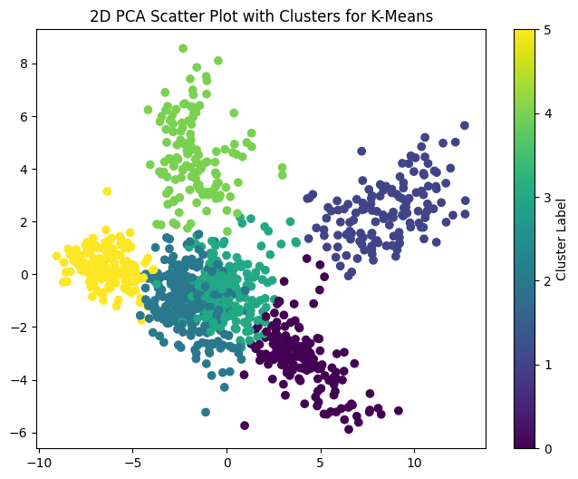

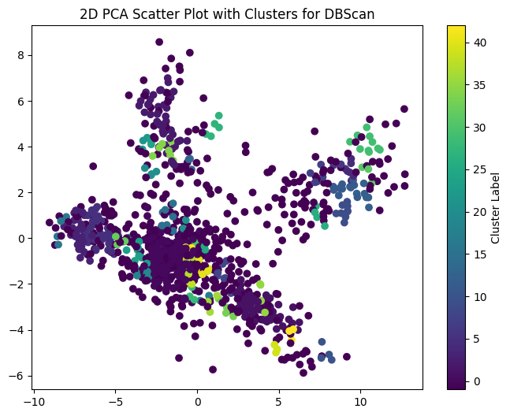

```python
plot_clusters(reducedData, KMPred, "K-Means")
plot_clusters(reducedData, DBPred, "DBScan")
```

# Analyzing Results

## Question 8: Explain how to calculate silhouette and homogeneity criteria.

### Silhouette Score

The Silhouette Score is a measure of how similar an object is to its own cluster compared to other clusters. It ranges from -1 to 1, where a high value indicates that the object is well matched to its own cluster and poorly matched to neighboring clusters.

#### Calculation Steps:

1. **Compute a(i):** For each point, calculate the average distance from all other points in the same cluster (intra-cluster distance).
2. **Compute b(i):** For the same point, calculate the average distance from all points in the nearest cluster that the point is not a part of (nearest-cluster distance).
3. **Silhouette Score for a Point:** The Silhouette Score ( S(i) ) for each point is then given by: $$ S(i) = \frac{b(i) - a(i)}{\max\{a(i), b(i)\}} $$
4. **Overall Silhouette Score:** The overall score is the average of the Silhouette Scores for all points.

### Homogeneity Score

Homogeneity Score measures if each cluster contains only members of a single class.

#### Calculation Steps:

1. **Cluster Labels and True Labels:** Consider the cluster labels assigned by the algorithm and the true labels of the data.
2. **Compute Homogeneity:** Calculate how much of each cluster is dedicated to the most common class in that cluster. The formula is: $$ H = 1 - \frac{H(C|K)}{H(C)} $$ where ( H(C|K) ) is the conditional entropy of the class distribution given the cluster assignment and ( H(C) ) is the entropy of the class distribution.
3. **Interpretation:** A score of 1 means perfect homogeneity, whereas a score close to 0 means low homogeneity.

### Conclusion

The Silhouette Score provides a measure of how well each object lies within its cluster, and the Homogeneity Score quantifies whether each cluster is composed of a single class. Both are crucial for evaluating the performance of clustering algorithms.

```python
KMHomo = homogeneity_score(y_test, KMPred)
DBHomo = homogeneity_score(y_test, DBPred)
print(f"Homogeneity Score for K-Means: {KMHomo:.4f}")
print(f"Homogeneity Score for DBSCAN : {DBHomo:.4f}")
```

```
Homogeneity Score for K-Means: 0.5560
Homogeneity Score for DBSCAN : 0.3870
```

```python
KMSil = silhouette_score(x_test, KMPred)
DBSil = silhouette_score(x_test, DBPred)
print(f"Silhouette  Score for K-Means: {KMSil:.4f}")
print(f"Silhouette  Score for DBSCAN : {DBSil:.4f}")
```

```
Silhouette  Score for K-Means: 0.4070
Silhouette  Score for DBSCAN : -0.3394
```

## Question 10: Suggest ways to improve the performance of the models.

- Optimzing Parameters in each method
- Better preprocessing
- Using better feature extracting models better than doc2vec